# Data Visualization - Project 2

Stefano Meschiari

August 1, 2015

This document contains my visualization of the “Astrophysics Collaborations” dataset (M. E. J. Newman, Proc. Natl. Acad. Sci. USA 98, 404-409, 2001). In this data, astronomers were connected if they co-authored a scientific paper together. The network of authors was derived by analyzing data from the astro-ph section of the ArXiv (a repository of scientific papers and preprints). The raw data is available [here](https://networkdata.ics.uci.edu/data.php?id=13).

## Graph

The dataset contains 16,706 nodes and 121,251 edges. Given the sheer number of geometric elements that would be required, I took a random sample of the network comprising 500 authors. The plot shows the connection between authors and their co-authors.

The structure of the network is not immediately evident from the graph alone, but there are a couple of immediate features: (1) two and three-author networks are very common (see next section); (2) several portion of the graph resemble trees, where nodes have several long branches with children and grandchildren (likely due to advisorship in academia).

The plot is drawn using D3.js and networkD3; you can zoom in by scrolling inside the plot rectangle.

[interactive chart not shown]

## Structure

The following plot shows the distribution of the degrees for each author (i.e., the number of co-authors connected to each author). It shows the power-law distribution that is [typical for networks](https://en.wikipedia.org/wiki/Scale-free_network), where N(k) ~ k<sup>-a</sup>, where a is typically between 2 and 3 for large k (k is the number of edges around each node, and N is the number of nodes).

There is a clear “knee” in the connectedness of authors around k ~ 30 (30 co-authors). For k > 30, the number of authors with a given number of co-authors decreases very quickly. This might reflect a sort of “saturation”, given the finite amount of authors available in each sub-field of Astronomy available for collaborations. I plotted two power-law fits for k < 30 and k > 30.

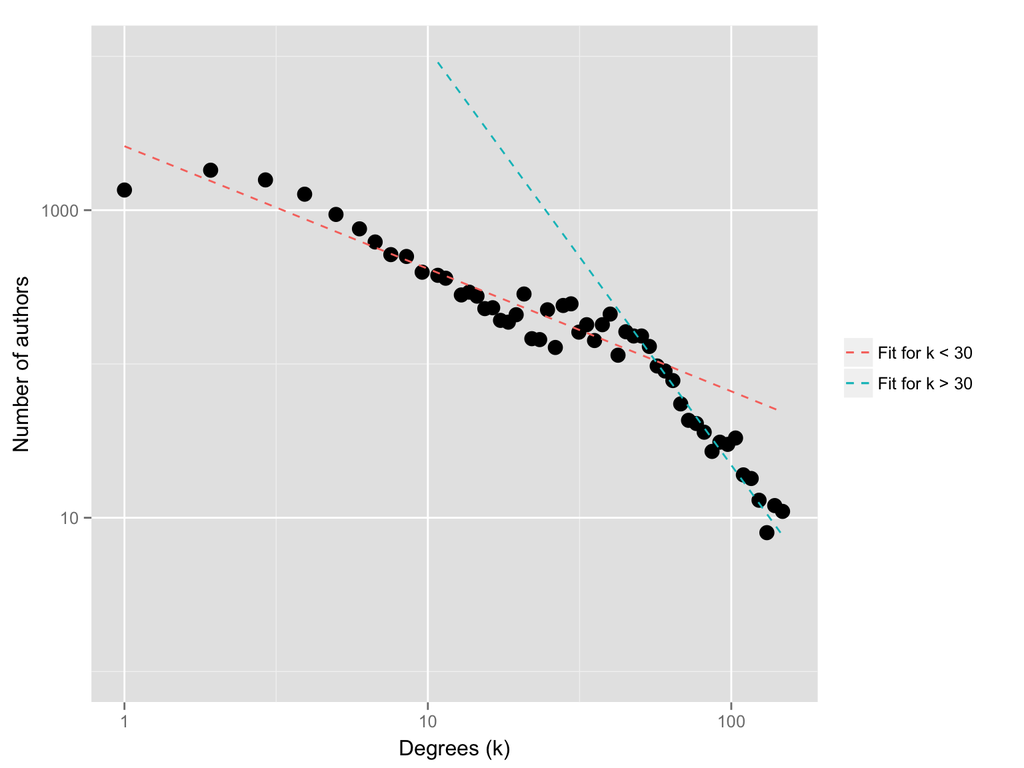